# Petiole Width to Leaf Mass Area

The goal of this markdown is to show the paths taken to creating a model based off of a living data set that makes prediction intervals for LMA of a fossil data set. Once LMA is found, we will be able to gain phylogenetic information from a model that predicts phylogeny based off of LMA. This is being done to work on improving fossil species predictions when using taxonomic analysis of functional traits.

```r
require(BIEN)
require(plyr)
require(tidyr)
require(dplyr)
```

```r
require(mosaic)
require(stringr)
require(lme4)
require(magrittr)
require(data.table)
require(knitr)
require(kableExtra)
library(dataCompareR)
require(utils)
```

First we must load all the processed data

```r
royer_tax_new<-read.csv(file="../data/processed/royer_tax_new.csv")
all_fossil_royer_pred<-read.csv(file="../data/processed/all_fossil_royer_pred.csv")
```

We must determine which mixed effects model is best suited to make prediction intervals. Using intercept effects super order, order, and scrubbed family and a slope effect of log pet leaf area, we determine the most suitable model by running a maximum likelihood ANOVA test and looking at the outputs in LogLik, AIC, dAIC, and p value. These are shown in the following table.

```r
model1<-lmer(log_lma~log_pet_leafarea + (1+log_pet_leafarea|superorder/order/scrubbed_family), data=royer_tax_new)
```

```
## boundary (singular) fit: see ?isSingular
```

```r
model2<-lmer(log_lma~log_pet_leafarea+(1+log_pet_leafarea|order/scrubbed_family), data=royer_tax_new)
model3<-lmer(log_lma~log_pet_leafarea + (1+log_pet_leafarea|scrubbed_family), data=royer_tax_new)
model4<-lmer(log_lma~log_pet_leafarea + (1|superorder/order/scrubbed_family), data=royer_tax_new)
```

```
## boundary (singular) fit: see ?isSingular
```

```r
model5<-lmer(log_lma~log_pet_leafarea + (1|order/scrubbed_family), data=royer_tax_new)
```

```
## boundary (singular) fit: see ?isSingular
```

```r
model6<-lmer(log_lma~log_pet_leafarea + (1|scrubbed_family), data=royer_tax_new)

modcompare<-anova(model1, model2, model3, model4, model5, model6)
```

```
## refitting model(s) with ML (instead of REML)
```

```r
ModelTable2<-data.frame("Model"=c(6, 3, 5, 2, 4, 1), "Rank"=c(1:6), "Slope Effects"=c("", "LPL","LPL", "", "LPL", ""), "Intercept Effects"=c("SF", "SF", "O, SF", "O, SF", "SO, O, SF", "SO, O, SF"), "LogLik"=c(-187.25, -184.00, -187.20, -183.69, -187.20, -183.32), "AIC"=c(382.49, 380.00, 384.40, 385.37, 386.40, 390.64), "dAIC"=c(0, -2.49, 4.40, 5.37, 6.40, 10.64))

table<-kable(ModelTable2, align='c')%>%
  kable_styling(bootstrap_options="striped", full_width=F)
table
```

[output not shown]

```r
model3<-lmer(log_lma~log_pet_leafarea + (1+log_pet_leafarea|scrubbed_family), data=royer_tax_new)
```

In order to compare our fossil data set to the living data set, we must omit predictions from all_fossil_royer_pred that aren’t present in royer_tax_new so all observations in the fossil data set are accounted for.

```r
options(max.print = 1000)
af<-royer_tax_new$scrubbed_family
af
```

```
##   [1] Lauraceae      Cornaceae      Thymelaeaceae  Ericaceae
##   [5] Rosaceae       Rosaceae       Fabaceae       Fabaceae
##   [9] Fabaceae       Fabaceae       Fabaceae       Fabaceae
##  [13] Fabaceae       Fabaceae       Fabaceae       Sapindaceae
##  [17] Sapindaceae    Sapindaceae    Sapindaceae    Sapindaceae
##  [21] Sapindaceae    Myrtaceae      Euphorbiaceae  Oleaceae
##  [25] Lamiaceae      Proteaceae     Myrtaceae      Euphorbiaceae
##  [29] Sapindaceae    Rhamnaceae     Rubiaceae      Rosaceae
##  [33] Rosaceae       Fabaceae       Fabaceae       Annonaceae
##  [37] Annonaceae     Ericaceae      Ericaceae      Ericaceae
##  [41] Malvaceae      Malvaceae      Apocynaceae    Araliaceae
##  [45] Myrtaceae      Euphorbiaceae  Proteaceae     Thymelaeaceae
##  [49] Proteaceae     Thymelaeaceae  Proteaceae     Thymelaeaceae
##  [53] Proteaceae     Thymelaeaceae  Asteraceae     Lauraceae
##  [57] Proteaceae     Rhamnaceae     Fabaceae       Betulaceae
```

[output cut: 78 more lines]

```r
bf<-all_fossil_royer_pred$scrubbed_family
bf
```

```
##   [1] Fagaceae          Anacardiaceae     Rosaceae
##   [4] Rosaceae          Hydrangeaceae     Hydrangeaceae
##   [7] Hydrangeaceae     Fagaceae          Fabaceae
##  [10] Rosaceae          Fabaceae          Fagaceae
##  [13] Meliaceae         Rosaceae          Rosaceae
##  [16] Salicaceae        Rosaceae          Fabaceae
##  [19] Anacardiaceae     Anacardiaceae     Anacardiaceae
##  [22] Hydrangeaceae     Hydrangeaceae     Rosaceae
##  [25] Salicaceae        Fagaceae          Fagaceae
##  [28] Fagaceae          Anacardiaceae     Anacardiaceae
##  [31] Anacardiaceae     Anacardiaceae     Anacardiaceae
##  [34] Rosaceae          Rosaceae          Rosaceae
##  [37] Staphyleaceae     Ulmaceae          Sapindaceae
##  [40] Sapindaceae       Sapindaceae       Sapindaceae
##  [43] Sapindaceae       Sapindaceae       Sapindaceae
```

[output cut: 78 more lines]

```r
##whats in all_fossil_royer_pred that isn't in #royer_tax_new

missing<-bf[!(bf%in%af)]
write.csv(missing, file="../data/missing.csv")

missing<-read.csv("../data/missing.csv")
missingdata<-subset(missing, select=-X)
colnames(missingdata)[colnames(missingdata)=="x"]<-"scrubbed_family"

tallymissing<-
  missingdata%>%
  group_by(scrubbed_family)%>%
  tally()
print.data.frame(tallymissing)
```

```
##      scrubbed_family  n
## 1       Altingiaceae  1
## 2      Anacardiaceae 26
## 3  Cercidiphyllaceae 12
## 4         Garryaceae  1
## 5    Grossulariaceae  1
## 6     Hamamelidaceae  4
## 7      Hydrangeaceae  7
## 8         Lythraceae  2
## 9         Myricaceae  2
## 10       Platanaceae  1
## 11       Smilacaceae  1
## 12     Staphyleaceae  3
## 13          Ulmaceae 21
```

```r
new_fossil_royer_pred2<-all_fossil_royer_pred[!all_fossil_royer_pred$scrubbed_family %in% missingdata$scrubbed_family,]
```

Then, prediction intervals are created for LMA in new_fossil_royer_pred2 based on model 3. The dataset contains observations for expected LMA, but this gives prediction intervals for log LMA that give a more picture of what those values should be.

```r
##Prediction Intervals
require(merTools)
PI<-predictInterval(merMod=model3, newdata=new_fossil_royer_pred2,
                    level=0.95, n.sims=1000,
                    stat="median", type="linear.prediction",
                    include.resid.var = TRUE)
PI
```

```
##          fit      upr      lwr
## 1   5.138462 5.883672 4.350801
## 2   4.974459 5.761670 4.174646
## 3   4.916858 5.696572 4.074997
## 4   4.866001 5.598471 4.145595
## 5   4.845907 5.592688 4.102159
## 6   4.228097 4.998351 3.453297
## 7   4.924660 5.678688 4.184207
## 8   4.793243 5.543537 4.020416
## 9   4.943998 5.699187 4.174042
## 10  5.052651 5.788725 4.299724
## 11  4.837344 5.586511 4.027981
## 12  4.295768 5.042516 3.516520
## 13  4.766802 5.521201 3.984345
## 14  4.954773 5.688566 4.191129
```

[output cut: 179 more lines]

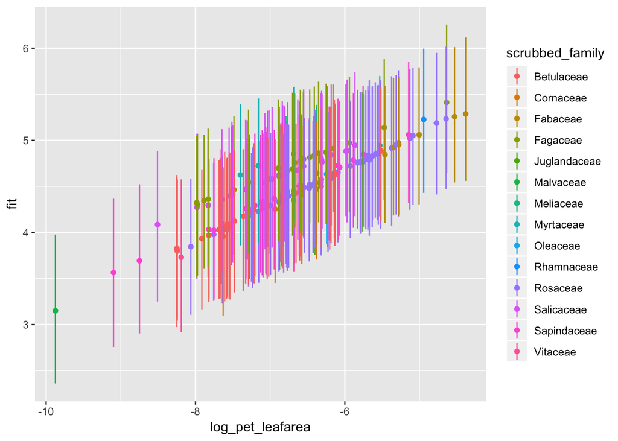

```r
fossilpredictions<-cbind(new_fossil_royer_pred2,PI)
library(ggplot2);
ggplot(aes(x=log_pet_leafarea, y=fit, ymin=lwr, ymax=upr, color=new_fossil_royer_pred2$scrubbed_family), data=fossilpredictions) +
  geom_point() +
  geom_linerange() +
  labs(color='scrubbed_family')
```

Save fossil predictions and eliminate unnecessary columns

```r
fossilpredictionsfinal<-fossilpredictions[-c(2, 4, 5, 6, 7, 8)]
write.csv(fossilpredictionsfinal, file="../data/processed/fossilpredictionsfinal.csv")
```